# Machine Learning (Clustering)

Muhammad Rifky Yusdiansyah

August 29, 2019

Description : To apply k-means clustering and hierarchical clustering Data provided on https://github.com/arikunco/machinelearning/blob/master/dataset/online_retail_clean.csv

```r
library(cluster)
library(DataExplorer)
```

```r
x <- read.csv("https://raw.githubusercontent.com/arikunco/machinelearning/master/dataset/online_retail_clean.csv")
```

liat 6 data pertama

```r
head(x)
```

|  | CustomerID | recency | frequency | monetary |
| --- | --- | --- | --- | --- |
| 1 | 12680 | 21.46528 | 2 | 68.40 |
| 2 | 15311 | 21.50000 | 36 | 1081.75 |
| 3 | 14446 | 21.51806 | 3 | 18.26 |
| 4 | 12518 | 21.57431 | 4 | 124.38 |
| 5 | 14441 | 21.62014 | 1 | 59.40 |
| 6 | 13883 | 22.19444 | 3 | 32.95 |

ambil kolom ke 2 sampe 4

```r
x<-x[,2:4]
head(x)
```

|  | recency | frequency | monetary |
| --- | --- | --- | --- |
| 1 | 21.46528 | 2 | 68.40 |
| 2 | 21.50000 | 36 | 1081.75 |
| 3 | 21.51806 | 3 | 18.26 |
| 4 | 21.57431 | 4 | 124.38 |
| 5 | 21.62014 | 1 | 59.40 |
| 6 | 22.19444 | 3 | 32.95 |

Berkenalan dulu dengan data (hint: summary(), dim(), plot())

```r
summary(x)
```

```
    recency         frequency         monetary
 Min.   : 21.47   Min.   : 1.000   Min.   :-38970.00
 1st Qu.: 47.43   1st Qu.: 1.000   1st Qu.:    13.20
 Median : 92.39   Median : 1.000   Median :    26.10
 Mean   :133.05   Mean   : 2.259   Mean   :    52.63
 3rd Qu.:203.47   3rd Qu.: 2.000   3rd Qu.:    56.73
 Max.   :394.51   Max.   :86.000   Max.   : 10122.56
```

Determine Number of Clusters using Elbow Method Initialize total within sum of squares error: wss

```r
wss <- 0
```

For 1 to 15 cluster centers

```r
iter.max=10
for (i in 1:15) {
  km.out <- kmeans(x[,1:3], centers = i, nstart = 20)
  # Save total within sum of squares to wss variable
  wss[i] <- km.out$tot.withinss
}
```

Plot total within sum of squares vs. number of clusters

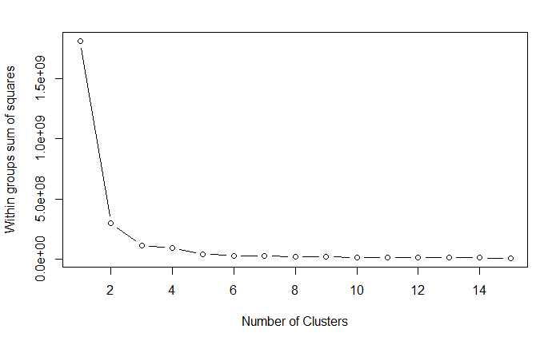

Determine Number of Clusters using Silhouette Method

```r
silhouette_score <- function(k){
  km <- kmeans(x, centers = k, nstart=20)
  ss <- silhouette(km$cluster, dist(x))
  mean(ss[, 3])
}
```

For 2 to 15 clusters

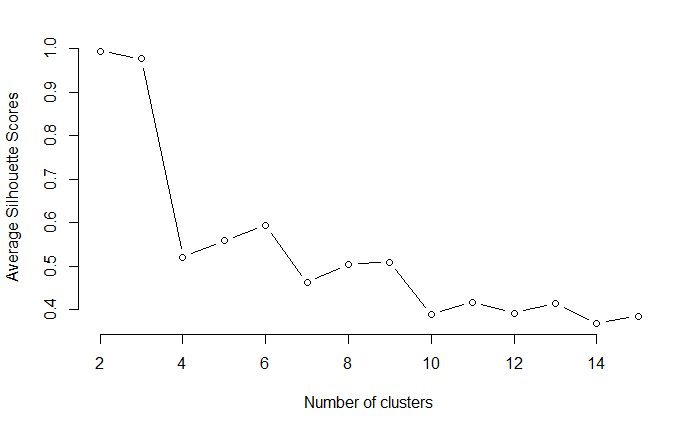

Maka banyaknya cluster yang digunakan adalah 3.

Menggunakan K-Means dengan K=3

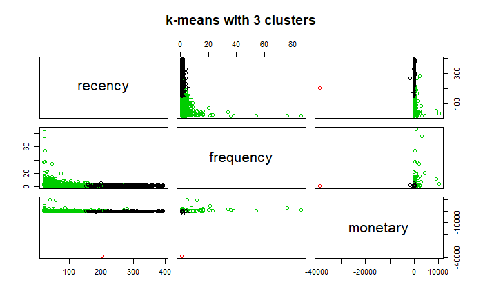

Membership

```r
km$cluster
```

[output not shown]

Berikut adalah data yang masuk kedalam cluster 1

```r
which(km$cluster %in% 1)
```

```
  [1] 1561 1567 1576 1578 1582 1584 1585 1587 1589 1590 1593 1600 1601 1602 1603 1604 1605 1606 1609 1610 1611 1612 1613 1614
 [25] 1615 1616 1617 1619 1620 1621 1623 1624 1625 1626 1627 1628 1629 1630 1631 1632 1633 1634 1635 1636 1638 1640 1642 1643
 [49] 1645 1646 1648 1649 1650 1651 1652 1654 1655 1656 1657 1658 1659 1660 1661 1662 1663 1664 1665 1666 1667 1668 1669 1670
 [73] 1671 1672 1673 1674 1676 1678 1680 1683 1684 1685 1686 1687 1688 1689 1690 1691 1692 1693 1694 1695 1696 1697 1698 1699
 [97] 1700 1701 1702 1703 1704 1705 1706 1707 1708 1709 1710 1711 1712 1713 1714 1715 1716 1717 1718 1719 1720 1721 1722 1723
[121] 1724 1725 1726 1727 1729 1731 1732 1733 1734 1736 1737 1738 1739 1740 1741 1742 1743 1744 1745 1746 1747 1748 1749 1750
[145] 1751 1752 1753 1754 1755 1756 1757 1758 1759 1760 1762 1763 1764 1765 1766 1767 1768 1769 1770 1771 1772 1773 1774 1775
[169] 1776 1777 1778 1779 1781 1782 1783 1784 1785 1786 1787 1788 1789 1790 1791 1792 1793 1794 1796 1797 1798 1799 1800 1801
[193] 1802 1803 1804 1805 1806 1807 1808 1809 1810 1811 1813 1814 1815 1816 1817 1818 1820 1822 1823 1824 1825 1826 1827 1828
[217] 1829 1830 1831 1832 1833 1834 1835 1836 1838 1839 1840 1841 1842 1843 1844 1845 1846 1847 1848 1849 1850 1851 1852 1853
[241] 1854 1855 1856 1857 1858 1859 1860 1861 1862 1863 1864 1865 1866 1867 1868 1869 1870 1871 1872 1873 1874 1875 1876 1877
[265] 1878 1879 1880 1881 1882 1883 1884 1885 1886 1887 1888 1889 1890 1891 1892 1893 1894 1895 1896 1897 1898 1899 1900 1901
[289] 1902 1903 1904 1905 1906 1907 1908 1909 1910 1911 1912 1913 1914 1915 1916 1917 1918 1919 1920 1921 1922 1923 1924 1925
[313] 1926 1927 1928 1929 1930 1931 1932 1933 1934 1935 1936 1937 1938 1939 1940 1941 1942 1943 1944 1945 1946 1947 1948 1949
[337] 1950 1951 1952 1953 1954 1955 1956 1957 1958 1959 1960 1961 1962 1963 1964 1965 1966 1967 1968 1969 1970 1971 1972 1973
```

[output cut: 17 more lines]

```r
paste("Data in cluster: ",as.character(length(which(km$cluster %in% 1))))
```

```
[1] "Data in cluster:  760"
```

Berikut adalah data yang masuk kedalam cluster 2

```r
which(km$cluster %in% 2)
```

```
[1] 1780
```

```r
paste("Data in cluster: ",as.character(length(which(km$cluster %in% 2))))
```

```
[1] "Data in cluster:  1"
```

Berikut adalah data yang masuk kedalam cluster 3

```r
which(km$cluster %in% 3)
```

```
   [1]    1    2    3    4    5    6    7    8    9   10   11   12   13   14   15   16   17   18   19   20   21   22   23   24
  [25]   25   26   27   28   29   30   31   32   33   34   35   36   37   38   39   40   41   42   43   44   45   46   47   48
  [49]   49   50   51   52   53   54   55   56   57   58   59   60   61   62   63   64   65   66   67   68   69   70   71   72
  [73]   73   74   75   76   77   78   79   80   81   82   83   84   85   86   87   88   89   90   91   92   93   94   95   96
  [97]   97   98   99  100  101  102  103  104  105  106  107  108  109  110  111  112  113  114  115  116  117  118  119  120
 [121]  121  122  123  124  125  126  127  128  129  130  131  132  133  134  135  136  137  138  139  140  141  142  143  144
 [145]  145  146  147  148  149  150  151  152  153  154  155  156  157  158  159  160  161  162  163  164  165  166  167  168
 [169]  169  170  171  172  173  174  175  176  177  178  179  180  181  182  183  184  185  186  187  188  189  190  191  192
 [193]  193  194  195  196  197  198  199  200  201  202  203  204  205  206  207  208  209  210  211  212  213  214  215  216
 [217]  217  218  219  220  221  222  223  224  225  226  227  228  229  230  231  232  233  234  235  236  237  238  239  240
 [241]  241  242  243  244  245  246  247  248  249  250  251  252  253  254  255  256  257  258  259  260  261  262  263  264
 [265]  265  266  267  268  269  270  271  272  273  274  275  276  277  278  279  280  281  282  283  284  285  286  287  288
 [289]  289  290  291  292  293  294  295  296  297  298  299  300  301  302  303  304  305  306  307  308  309  310  311  312
 [313]  313  314  315  316  317  318  319  320  321  322  323  324  325  326  327  328  329  330  331  332  333  334  335  336
 [337]  337  338  339  340  341  342  343  344  345  346  347  348  349  350  351  352  353  354  355  356  357  358  359  360
```

[output cut: 28 more lines]

```r
paste("Data in cluster: ",as.character(length(which(km$cluster %in% 3))))
```

```
[1] "Data in cluster:  1614"
```

Data beserta cluster akan disimpan pada data frame bernama df

|  | recency | frequency | monetary | cluster |
| --- | --- | --- | --- | --- |
| 1 | 21.46528 | 2 | 68.40 | 3 |
| 2 | 21.50000 | 36 | 1081.75 | 3 |
| 3 | 21.51806 | 3 | 18.26 | 3 |
| 4 | 21.57431 | 4 | 124.38 | 3 |
| 5 | 21.62014 | 1 | 59.40 | 3 |
| 6 | 22.19444 | 3 | 32.95 | 3 |

Ini adalah 6 data pertama yang masuk pada cluster 1

|  | recency | frequency | monetary | cluster |
| --- | --- | --- | --- | --- |
| 1561 | 150.2715 | 1 | 2.95 | 1 |
| 1567 | 151.4917 | 1 | 1.25 | 1 |
| 1576 | 152.5083 | 1 | 2.95 | 1 |
| 1578 | 154.4389 | 1 | 14.50 | 1 |
| 1582 | 155.2854 | 1 | 0.00 | 1 |
| 1584 | 155.3187 | 2 | 5.20 | 1 |

```r
summary(df[df$cluster==1,])[,1:3]
```

```
    recency        frequency        monetary
 Min.   :150.3   Min.   :1.000   Min.   :-1781.46
 1st Qu.:206.5   1st Qu.:1.000   1st Qu.:   10.07
 Median :260.3   Median :1.000   Median :   17.40
 Mean   :266.4   Mean   :1.274   Mean   :   22.45
 3rd Qu.:319.5   3rd Qu.:1.000   3rd Qu.:   32.70
 Max.   :394.5   Max.   :6.000   Max.   :  337.10
```

Ini adalah yang masuk pada cluster 2

|  | recency | frequency | monetary | cluster |
| --- | --- | --- | --- | --- |
| 1780 | 203.3535 | 1 | -38970 | 2 |

Ini adalah 6 data pertama yang masuk pada cluster 3

|  | recency | frequency | monetary | cluster |
| --- | --- | --- | --- | --- |
| 1 | 21.46528 | 2 | 68.40 | 3 |
| 2 | 21.50000 | 36 | 1081.75 | 3 |
| 3 | 21.51806 | 3 | 18.26 | 3 |
| 4 | 21.57431 | 4 | 124.38 | 3 |
| 5 | 21.62014 | 1 | 59.40 | 3 |
| 6 | 22.19444 | 3 | 32.95 | 3 |

```r
summary(df[df$cluster==3,])[,1:3]
```

```
    recency         frequency         monetary
 Min.   : 21.47   Min.   : 1.000   Min.   :  -76.50
 1st Qu.: 39.48   1st Qu.: 1.000   1st Qu.:   15.11
 Median : 59.56   Median : 2.000   Median :   34.60
 Mean   : 70.23   Mean   : 2.724   Mean   :   91.02
 3rd Qu.: 94.43   3rd Qu.: 3.000   3rd Qu.:   71.81
 Max.   :280.55   Max.   :86.000   Max.   :10122.56
```

Dan berikut adalah center dari k-means dengan cluster 3

```r
km$centers
```

```
    recency frequency     monetary
1 266.36667  1.273684     22.45083
2 203.35347  1.000000 -38970.00000
3  70.23071  2.724287     91.01791
```

Kode untuk Hierarchical Clustering

Berkenalan dulu dengan data

```r
summary(x)
```

```
    recency         frequency         monetary
 Min.   : 21.47   Min.   : 1.000   Min.   :-38970.00
 1st Qu.: 47.43   1st Qu.: 1.000   1st Qu.:    13.20
 Median : 92.39   Median : 1.000   Median :    26.10
 Mean   :133.05   Mean   : 2.259   Mean   :    52.63
 3rd Qu.:203.47   3rd Qu.: 2.000   3rd Qu.:    56.73
 Max.   :394.51   Max.   :86.000   Max.   : 10122.56
```

```r
dim(x)
```

```
[1] 2375    3
```

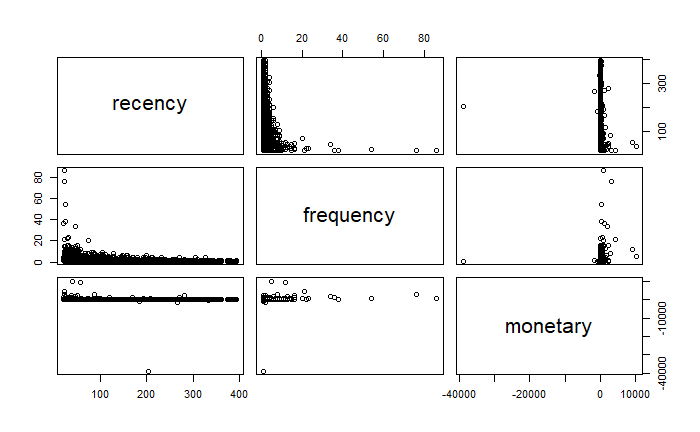

Calculates similarity as Euclidean distance between observations

```r
d <- dist(x[,1:4])
```

[output not shown]

Returns hierarchical clustering model

```r
summary(hclust.out)
```

```
            Length Class  Mode
merge       4748   -none- numeric
height      2374   -none- numeric
order       2375   -none- numeric
labels         0   -none- NULL
method         1   -none- character
call           2   -none- call
dist.method    1   -none- character
```

Draws a dendrogram

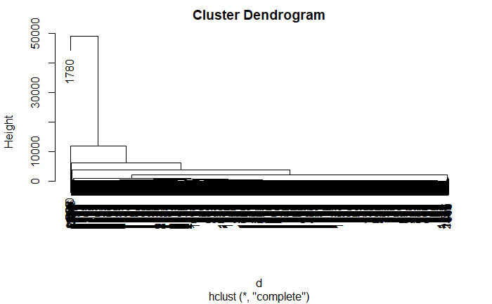

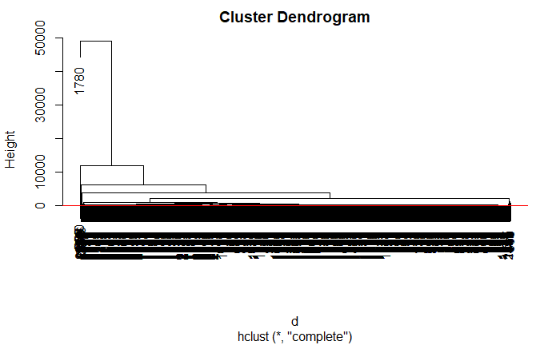

```r
plot(hclust.out)
plot(hclust.out)

abline(h = 3.5, col = "red")
```

Cut by height h

```r
cutree(hclust.out, h = 6)
```

```
   [1]   1   2   3   4   5   6   7   3   3   8   9  10   3   7  11  12   3  13  14   7  15  16  17   1   8  18  14  19   6   8
  [31]  20   9  16  21   7  22   9  15  13  23  13   7  24  25   9  13  22   7   3   3  26  25  27  21  28   1  29   5  30  31
  [61]  14  22  28   6  29  14  31  32  24  28  26  22   7  22  33  33  34  35   8  36   1   3  36  37  30  37  25  34   6  25
  [91]  25   3  38  25  21   8   6  39  40  25  41  15  16  42  16  43  43  25  25  34  32  44  45  17  28  29  25   8  46  27
 [121]  47  14   7  25  31  48  28  43  34  34  49  27  50  51  28  25  52  25  14  53  24  54  46  52  55  28  28  56  36  17
 [151]  57  58  59  60  61  62  52  63  64  65  54  51  24  58  66  67  58  56  24  68  51  61  69  70  71  72  63  66  73  51
 [181]  60  61  74  75  75  64  76  77  78  75  61  52  70  79  69  52  79  80  69  81  82  69  79  73  83  71  58  70  84  85
 [211]  72  54  52  79  69  69  69  86  64  66  64  57  75  75  84  64  87  88  89  90  90  77  76  84  91  90  79  76  92  93
 [241]  62  94  74  75  93  95  75  96  93  96  89  79  89  89  97  88  83  98  99  96  88 100 101  91 102  93 103 101  60 101
 [271]  97 104 102 101 105  93  93  96 105 105 101  93 105 101  84 106  93 102  96 107  89 102 108 109 109  89 110 111  89  91
 [301] 101 112 102  89 113 109 114 115 112 116 116 104 101 109 117  89 107 118  89 119 109 112  91 112 112 120 121 122 115 115
 [331] 111 112 114 123 124 125 123 126 127 114 112 128 109 129 130 115 115  99 114 131 118 112 132 133 123 118 134 131 127 109
 [361] 135 123 133 133 136 112 137 132 112 123 138 136 115 131 115 121 131 127 112 108 129 111 112 139 134 118 124 110 124 130
 [391] 114 127 140 141 116 131 124 112 142 134 131 143 131 144 121 127 115 112 115 145 129 127 146 111 147 136 115 115 112 148
 [421] 112 143 120 149 149 112 112 143 143 144 146 124 124 112 149 150 137 151 123 121 143 112 149 148 152 143 153 150 143 153
```

[output cut: 20 more lines]

Cut by number of clusters

```r
cutree(hclust.out, k = 3)
```

[output not shown]

Data yang masuk ke cluster 1

```r
which(cutree(hclust.out, k = 3) %in% 1)
```

```
   [1]    1    2    3    4    5    6    7    8    9   10   11   12   13   14   15   16   17   18   19   20   21   22   23   24
  [25]   25   26   27   28   29   30   31   32   33   34   35   36   37   38   39   40   41   42   43   44   45   46   47   48
  [49]   49   50   51   52   53   54   55   56   57   58   59   60   61   62   63   64   65   66   67   68   69   70   71   72
  [73]   73   74   75   76   77   78   79   80   81   82   83   84   85   86   87   88   89   90   91   92   93   94   95   96
  [97]   97   98   99  100  101  102  103  104  105  106  107  108  109  110  111  112  113  114  115  116  117  118  119  120
 [121]  121  122  123  124  125  126  127  128  129  130  131  132  133  134  135  136  137  138  139  140  141  142  143  144
 [145]  145  146  147  148  149  150  151  152  153  154  155  156  157  158  159  160  161  162  163  164  165  166  167  168
 [169]  169  170  171  172  173  174  175  176  177  178  179  180  181  182  183  184  185  186  187  188  189  190  191  192
 [193]  193  194  195  196  197  198  199  200  201  202  203  204  205  206  207  208  209  210  211  212  213  214  215  216
 [217]  217  218  219  220  221  222  223  224  225  226  227  228  229  230  231  232  233  234  235  236  237  238  239  240
 [241]  241  242  243  244  245  246  247  248  249  250  251  252  253  254  255  256  257  258  259  260  261  262  263  264
 [265]  265  266  267  268  269  270  271  272  273  274  275  276  277  278  279  280  281  282  283  284  285  286  287  288
 [289]  289  290  291  292  293  294  295  296  297  298  299  300  301  302  303  304  305  306  307  308  309  310  311  312
 [313]  313  314  315  316  317  318  319  320  321  322  323  324  325  326  327  328  329  330  331  332  333  334  335  336
 [337]  337  338  339  340  341  342  343  344  345  346  347  348  349  350  351  352  353  354  355  356  357  358  359  360
```

[output cut: 28 more lines]

```r
paste("Data in cluster: ",as.character(length(which(cutree(hclust.out, k = 3) %in% 1))))
```

```
[1] "Data in cluster:  2372"
```

Data yang masuk cluster 2

```r
which(cutree(hclust.out, k = 3) %in% 2)
```

```
[1] 399 755
```

```r
paste("Data in cluster: ",as.character(length(which(cutree(hclust.out, k = 3) %in% 2))))
```

```
[1] "Data in cluster:  2"
```

Data yang masuk cluster 3

```r
which(cutree(hclust.out, k = 3) %in% 3)
```

```
[1] 1780
```

```r
paste("Data in cluster: ",as.character(length(which(cutree(hclust.out, k = 3) %in% 3))))
```

```
[1] "Data in cluster:  1"
```

Fitting hierarchical clustering models using different methods

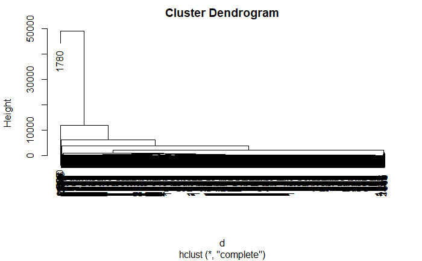

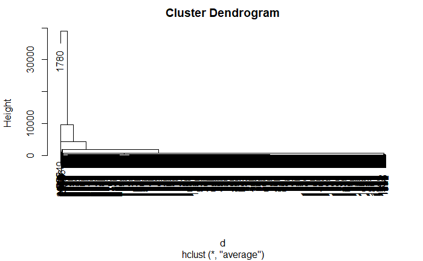

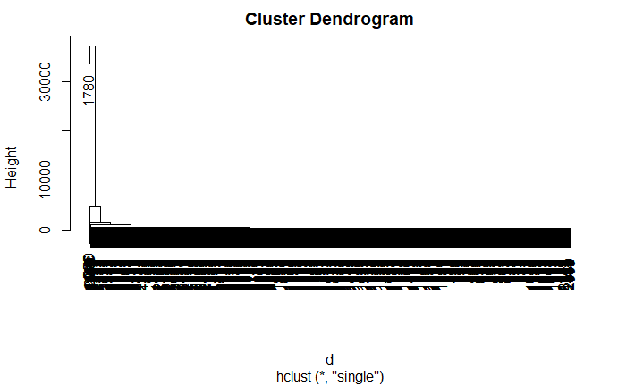